# Multiple linear regression

Last compiled: Nov 25, 2016

This is a product of OpenIntro that is released under a [Creative Commons Attribution-ShareAlike 3.0 Unported](http://creativecommons.org/licenses/by-sa/3.0). This lab was written by Mine Çetinkaya-Rundel and Andrew Bray and modified by Alan Arnholt.

Complete all **Exercises and Questions**. Submit your knitted html file to [crowdgrader](http://crowdgrader.com).

## Grading the professor

Many college courses conclude by giving students the opportunity to evaluate the course and the instructor anonymously. However, the use of these student evaluations as an indicator of course quality and teaching effectiveness is often criticized because these measures may reflect the influence of non-teaching related characteristics, such as the physical appearance of the instructor. The article titled, “Beauty in the classroom: instructors’ pulchritude and putative pedagogical productivity” (Hamermesh and Parker 2005) found that instructors who are judged more attractive receive higher instructional ratings.

In this lab, we will analyze the data from this study in order to learn what goes into a positive professor evaluation.

## Getting Started

### Load packages

In this lab, the `dplyr` package by Wickham and Francois (2016) is used to explore the data. Visualization of the data is accomplished with the `ggplot2` and `GGally` packages created by Wickham and Chang (2016) and Schloerke et al. (2016), respectively. The data resides in the `statsr` package created by Rundel et al. (2016). Tables are formatted for html with the `htmlTable` package created by Gordon (2016) and data is formatted for easy viewing with the `DT` package by Xie (2016).

Let us load the packages.

```r
library(statsr)
library(dplyr)
library(ggplot2)
library(GGally)
library(htmlTable)
library(DT)
```

This is the first time we have used the `GGally` package. We will use the `ggpairs` function from `GGally` later in the lab.

### The data

The data were gathered from end of semester student evaluations for a large sample of professors from the University of Texas at Austin. In addition, six students rated the professors’ physical appearance. (This is a slightly modified version of the original data set that was released as part of the replication data for *Data Analysis Using Regression and Multilevel/Hierarchical Models* (Gelman and Hill 2007).) The result is a data frame where each row contains a different course and columns represent variables about the courses and professors.

Let us load the data:

```r
data(evals)
```

Table 1: Variables and descriptions for `evals`

| variable | description |
| --- | --- |
| score | average professor evaluation score: (1) very unsatisfactory—(5) excellent. |
| rank | rank of professor: teaching, tenure track, tenured. |
| ethnicity | ethnicity of professor: not minority, minority. |
| gender | gender of professor: female, male. |
| language | language of school where professor received education: english or non-english. |
| age | age of professor. |
| cls_perc_eval | percent of students in class who completed evaluation. |
| cls_did_eval | number of students in class who completed evaluation. |
| cls_students | total number of students in class. |
| cls_level | class level: lower, upper. |
| cls_profs | number of professors teaching sections in course in sample: single, multiple. |
| cls_credits | number of credits of class: one credit (lab, PE, etc.), multi credit. |
| bty_f1lower | beauty rating of professor from lower level female: (1) lowest—(10) highest. |
| bty_f1upper | beauty rating of professor from upper level female: (1) lowest—(10) highest. |
| bty_m1lower | beauty rating of professor from lower level male: (1) lowest—(10) highest. |
| bty_m1upper | beauty rating of professor from upper level male: (1) lowest—(10) highest. |
| bty_m2upper | beauty rating of professor from second upper level male: (1) lowest—(10) highest. |
| bty_avg | average beauty rating of professor. |
| pic_outfit | outfit of professor in picture: not formal, formal. |
| pic_color | color of professor’s picture: color, black & white. |

```r
DT::datatable(evals)
```

|  | score | rank | ethnicity | gender | language | age | cls_perc_eval | cls_did_eval | cls_students | cls_level | cls_profs | cls_credits | bty_f1lower | bty_f1upper | bty_f2upper | bty_m1lower | bty_m1upper | bty_m2upper | bty_avg | pic_outfit | pic_color |
| --- | --- | --- | --- | --- | --- | --- | --- | --- | --- | --- | --- | --- | --- | --- | --- | --- | --- | --- | --- | --- | --- |
| 1 | 4.7 | tenure track | minority | female | english | 36 | 55.81395 | 24 | 43 | upper | single | multi credit | 5 | 7 | 6 | 2 | 4 | 6 | 5 | not formal | color |
| 2 | 4.1 | tenure track | minority | female | english | 36 | 68.8 | 86 | 125 | upper | single | multi credit | 5 | 7 | 6 | 2 | 4 | 6 | 5 | not formal | color |
| 3 | 3.9 | tenure track | minority | female | english | 36 | 60.8 | 76 | 125 | upper | single | multi credit | 5 | 7 | 6 | 2 | 4 | 6 | 5 | not formal | color |
| 4 | 4.8 | tenure track | minority | female | english | 36 | 62.60163 | 77 | 123 | upper | single | multi credit | 5 | 7 | 6 | 2 | 4 | 6 | 5 | not formal | color |
| 5 | 4.6 | tenured | not minority | male | english | 59 | 85 | 17 | 20 | upper | multiple | multi credit | 4 | 4 | 2 | 2 | 3 | 3 | 3 | not formal | color |
| 6 | 4.3 | tenured | not minority | male | english | 59 | 87.5 | 35 | 40 | upper | multiple | multi credit | 4 | 4 | 2 | 2 | 3 | 3 | 3 | not formal | color |
| 7 | 2.8 | tenured | not minority | male | english | 59 | 88.63636 | 39 | 44 | upper | multiple | multi credit | 4 | 4 | 2 | 2 | 3 | 3 | 3 | not formal | color |
| 8 | 4.1 | tenured | not minority | male | english | 51 | 100 | 55 | 55 | upper | single | multi credit | 5 | 2 | 5 | 2 | 3 | 3 | 3.333 | not formal | color |
| 9 | 3.4 | tenured | not minority | male | english | 51 | 56.92308 | 111 | 195 | upper | single | multi credit | 5 | 2 | 5 | 2 | 3 | 3 | 3.333 | not formal | color |
| 10 | 4.5 | tenured | not minority | female | english | 40 | 86.95652 | 40 | 46 | upper | single | multi credit | 2 | 5 | 4 | 3 | 3 | 2 | 3.167 | not formal | color |

[output cut: 453 more lines]

1. Is this an observational study or an experiment?
   1. Observational study
   2. Experiment

Type your answer for Question 1 between the answer tags and delete this comment.

2. The original research question posed in the paper is whether beauty leads directly to the differences in course evaluations. Given the study design, should the question be rephrased? If so, how?
   1. No, the question is worded accurately.
   2. Yes, revise wording to “Is there an association between beauty and course evaluations?”
   3. Yes, revise wording to “Does beauty score increase the professor’s course evaluations?”
   4. Yes, revise wording to “Does beauty score decrease the professor’s course evaluations?”

Type your answer for Question 2 between the answer tags and delete this comment.

## Exploring the data

3. Which of the following statements is **false** about the distribution of `score`?
   1. The median of the distribution is 4.3.
   2. 25% of the students gave their professors a score of over 4.6.
   3. 11 of students gave a professor a score below 3.
   4. The left skewness of the data suggests that the students are less likely to rate the professors highly.

```r
# Type your code for Question 3 here, and Knit.
```

Type your answer for Question 3 between the answer tags and delete this comment.

**Exercise 1:** Excluding `score`, select two other variables and describe their relationship using an appropriate visualization (scatterplot, side-by-side boxplots, or mosaic plot).

```r
# Type your code for the Exercise 1 here, and Knit.
```

Type your answer for Exercise 1 between the answer tags and delete this comment. - Answers will vary

## Simple linear regression

The fundamental phenomenon suggested by the study is that teachers judged more attractive are evaluated more favorably. Let us create a scatterplot to see if this appears to be the case:

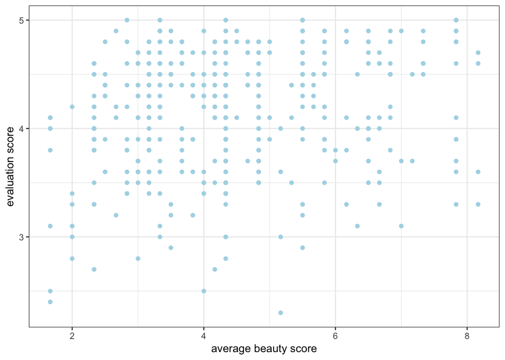

Figure 1: Score versus beauty average

```r
ggplot(data = evals, aes(x = bty_avg, y = score)) +
  geom_point(color = "lightblue") +
  theme_bw() +
  labs(x = "average beauty score", y = "evaluation score")
```

Before we draw conclusions about the trend in Figure 1, compare the number of observations in the data frame with the approximate number of points on the scatterplot. Is anything awry?

Type your answer here - answers may vary

**Exercise 2:** Replot the scatterplot, but this time replace the `geom_point()` layer with a `geom_jitter()` layer. (Use `?geom_jitter` to learn more.) What was misleading about the initial scatterplot?

```r
# Type your code for the Exercise 2 here, and Knit.
```

Type your answer for Exercise 2 between the answer tags and delete this comment. - Answers will vary

Is the apparent trend in the plot something more than natural variation? Fit a linear model called `modB` to predict average professor score by average beauty rating and add the line to your plot using the following. If you do not remember how to do this, refer to the previous lab.

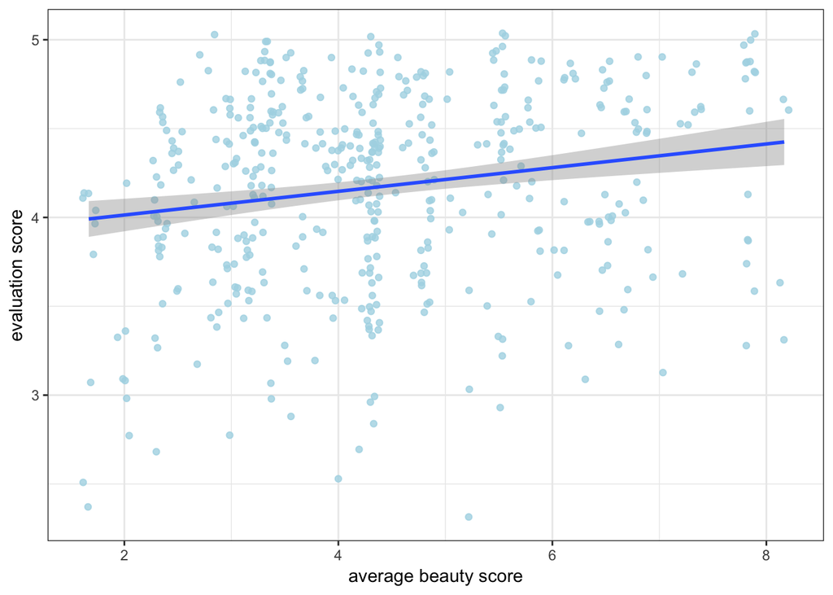

```r
ggplot(data = evals, aes(x = bty_avg, y = score)) +
  geom_jitter(color = "lightblue", alpha = 0.8) +
  geom_smooth(method = "lm") +
  theme_bw() +
  labs(x = "average beauty score", y = "evaluation score")
```

The blue line is the model. The shaded gray area around the line tells us about the variability we might expect in our predictions. To remove the confidence band, use `se = FALSE`.

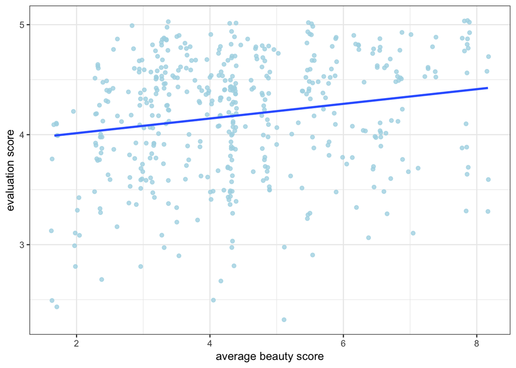

```r
ggplot(data = evals, aes(x = bty_avg, y = score)) +
  geom_jitter(color = "lightblue", alpha = 0.8) +
  geom_smooth(method = "lm", se = FALSE) +
  theme_bw() +
  labs(x = "average beauty score", y = "evaluation score")
```

**Exercise 3:** Print a summary of the linear model, write out the equation, and interpret the slope.

```r
# Type your code for the Exercise 3 here, and Knit.
```

Type your answer for Exercise 3 between the answer tags and delete this comment.

4. Average beauty score is a statistically significant predictor of evaluation score.
   1. True
   2. False

Type your answer for Question 4 between the answer tags and delete this comment.

5. Use residual plots to evaluate whether the conditions of least squares regression are reasonable. Which of the following statements is an incorrect analysis of the residual plots and conditions?
   1. Linear association: The residuals plot shows a random scatter.
   2. Constant variance of residuals: No fan shape in residuals plot.
   3. Nearly normal residuals: Residuals are right skewed, but the sample size is large, so this may not be an important violation of conditions.
   4. Independent observations: Classes sampled randomly, no order effect.

```r
# Type your code for the Question 5 here, and Knit.
# residual plot, Q-Q plot, and density plot of residuals
```

Type your answer for Question 5 between the answer tags and delete this comment.

## Multiple linear regression

The data set contains several variables on the beauty score of the professor as well as individual ratings from each of the six students who were asked to score the physical appearance of the professors. It also has a variable that is the average of these six scores. Let us examine the strength of the linear relationship between one of these scores (`bty_f1lower`) and the average beauty score (`bty_avg`).

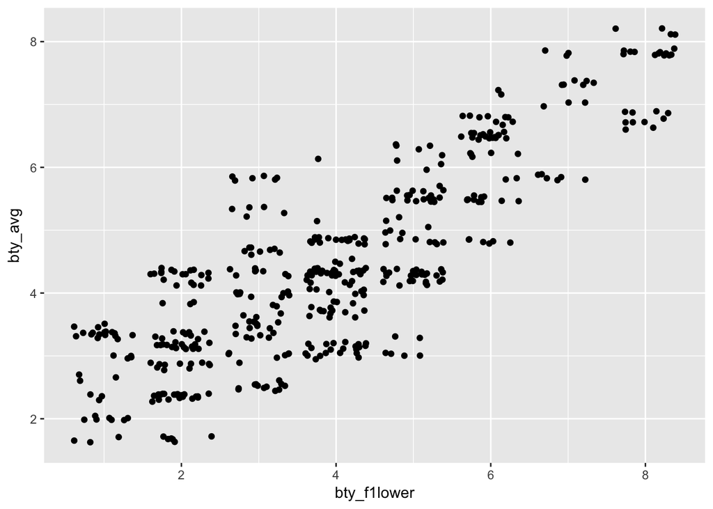

```r
ggplot(data = evals, aes(x = bty_f1lower, y = bty_avg)) +
  geom_jitter()
```

```r
# Correlation using cor()
# 1. Just the function
cor(evals$bty_avg, evals$bty_f1lower)
```

```
[1] 0.8439112
```

```r
# 2. Using with() to access the data
with(data = evals, cor(bty_avg, bty_f1lower))
```

```
[1] 0.8439112
```

```r
# 3. using a pipe
evals %>%
  summarise(r = cor(bty_avg, bty_f1lower))
```

```
# A tibble: 1 × 1
          r
      <dbl>
1 0.8439112
```

As expected, the relationship is quite strong—after all, the average score is calculated using the individual scores. Figure 2 depicts the relationships between all beauty variables (columns 13 through 19) using the following command:

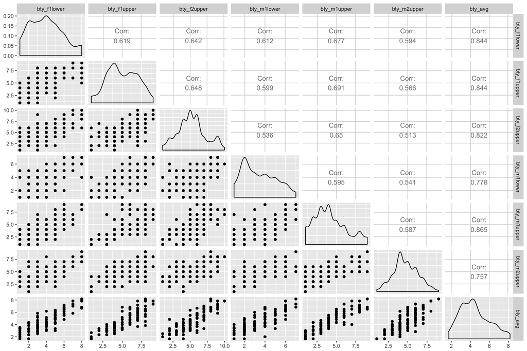

Figure 2: GGpairs matrix scatterplot

```r
# Note: This is a painfully slow function!
ggpairs(evals, columns = 13:19)
```

The variables in Figure 2 are collinear (correlated), and adding more than one of these variables to the model would not add much value to the model. In this application and with these highly-correlated predictors, it is reasonable to use the average beauty score as the single representative of these variables.

In order to see if beauty is still a significant predictor of professor score after we have accounted for the gender of the professor, we can add the gender term into the model.

```r
m_bty_gen <- lm(score ~ bty_avg + gender, data = evals)
summary(m_bty_gen)
```

```
Call:
lm(formula = score ~ bty_avg + gender, data = evals)

Residuals:
    Min      1Q  Median      3Q     Max
-1.8305 -0.3625  0.1055  0.4213  0.9314

Coefficients:
            Estimate Std. Error t value Pr(>|t|)
(Intercept)  3.74734    0.08466  44.266  < 2e-16 ***
bty_avg      0.07416    0.01625   4.563 6.48e-06 ***
gendermale   0.17239    0.05022   3.433 0.000652 ***
---
Signif. codes:  0 '***' 0.001 '**' 0.01 '*' 0.05 '.' 0.1 ' ' 1

Residual standard error: 0.5287 on 460 degrees of freedom
Multiple R-squared:  0.05912,   Adjusted R-squared:  0.05503
F-statistic: 14.45 on 2 and 460 DF,  p-value: 8.177e-07
```

| Table 2: `score` regressed on `bty_avg` and `gender` | Table 2: `score` regressed on `bty_avg` and `gender` Estimate | Table 2: `score` regressed on `bty_avg` and `gender` Std. Error | Table 2: `score` regressed on `bty_avg` and `gender` t value | Table 2: `score` regressed on `bty_avg` and `gender` Pr(>\|t\|) |
| --- | --- | --- | --- | --- |
| (Intercept) | 3.7473 | 0.0847 | 44.266 | 0 |
| bty_avg | 0.0742 | 0.0163 | 4.5628 | 0 |
| gendermale | 0.1724 | 0.0502 | 3.4326 | 7e-04 |

6. P-values and parameter estimates should only be trusted if the conditions for the regression are reasonable. Using diagnostic plots, we can conclude that the conditions for this model (`m_bty_gen`) may be reasonable.
   1. True
   2. False

```r
# Type your code to create appropriate diagnostic plots, and Knit.
```

Type your answer for Question 6 between the answer tags and delete this comment.

**Exercise 4:** Print a summary of the multiple linear regression model (`m_bty_gen`). Is `bty_avg` still a significant predictor of `score`? Has the addition of `gender` to the model changed the parameter estimate for `bty_avg`?

```r
# Type your code for Exercise 4 here, and Knit.
```

Type your answer for Exercise 4 between the answer tags and delete this comment.

Note that the estimate for `gender` is now called `gendermale`. The original variable name will change whenever you introduce a categorical variable. The reason the name changes is because R re-codes `gender` from having values `female` and `male` to an indicator variable called `gendermale` that takes a value of $0$ for females and a value of $1$ for males. (Such variables are often referred to as “dummy” variables.)

As a result, for females, the parameter estimate is multiplied by zero, leaving the intercept and slope form familiar from simple regression.

$$\begin{aligned}
\widehat{\text{score}} &= \hat{\beta}_0 + \hat{\beta}_1 \times \text{bty_avg} + \hat{\beta}_2 \times (0) \\
&= \hat{\beta}_0 + \hat{\beta}_1 \times \text{bty_avg}\end{aligned}$$

7. For two professors (one male and one female) who received the same beauty rating, the male professor is predicted to have the higher course evaluation score than the female.
   1. True
   2. False

Type your answer for Question 7 between the answer tags and delete this comment.

The decision to call the indicator variable `gendermale` instead of`genderfemale` has no deeper meaning. R simply codes the category that comes first alphabetically as a $0$. (You can change the reference level of a categorical variable, which is the level that is coded as a 0, using the`relevel` function; use `?relevel` to learn more.)

**Exercise 5:** Create a new model called `m_bty_rank` with `gender` removed and `rank` added to the model. How does R handle categorical variables that have more than two levels? Note that the rank variable has three levels: teaching, tenure track, and tenured.

```r
# Type your code for Exercise 5 here, and Knit.
```

Type your answer for Exercise 5 between the answer tags and delete this comment.

The interpretation of the coefficients in multiple regression is slightly different from that of simple regression. The estimate for `bty_avg` reflects how much higher a group of professors is expected to score if they have a beauty rating that is one point higher *while holding all other variables constant*. In this case, that translates into considering only professors of the same rank with `bty_avg` scores that are one point apart.

## Prediction

Suppose we want to use the model we created earlier, `m_bty_gen`, to predict the evaluation score for a professor, Dr. Hypo Thetical, who is a male tenure track professor with an average beauty score of 3.

If we wanted to do this by hand, we would “plug in” these values using the fitted linear model.

To compute the predicted value in R, create a new data frame for this professor.

```r
newprof <- data.frame(gender = "male", bty_avg = 3)
```

Note that I did not need to add `rank = "tenure track"` to this data frame since this variable is not used in our model.

Then, I can do the prediction using the `predict` function:

```r
predict(m_bty_gen, newdata = newprof)
```

```
       1
4.142194
```

We can also construct a prediction interval around this prediction, which will provide a measure of uncertainty around the prediction.

```r
PI <- predict(m_bty_gen, newdata = newprof, interval = "prediction", level = 0.95)
PI
```

```
       fit      lwr      upr
1 4.142194 3.100559 5.183829
```

The model predicts, with 95% confidence, that a male professor with an average beauty score of 3 is expected to have an evaluation score between 3.1005587 and 5.1838291.

## The search for the best model

We will start with a full model that predicts professor score based on rank, ethnicity, gender, language of the university where they got their degree, age, proportion of students that filled out evaluations, class size, course level, number of professors, number of credits, average beauty rating, outfit, and picture color.

**Think About**: Which variable would you expect to have the highest p-value in this model? Why? *Hint:* Think about which variable would you expect to not have any association with the professor score.

Let us run the model…

```r
m_full <- lm(score ~ rank + ethnicity + gender + language + age + cls_perc_eval
             + cls_students + cls_level + cls_profs + cls_credits + bty_avg
             + pic_outfit + pic_color, data = evals)
summary(m_full)
```

```
Call:
lm(formula = score ~ rank + ethnicity + gender + language + age +
    cls_perc_eval + cls_students + cls_level + cls_profs + cls_credits +
    bty_avg + pic_outfit + pic_color, data = evals)

Residuals:
     Min       1Q   Median       3Q      Max
-1.77397 -0.32432  0.09067  0.35183  0.95036

Coefficients:
                        Estimate Std. Error t value Pr(>|t|)
(Intercept)            4.0952141  0.2905277  14.096  < 2e-16 ***
ranktenure track      -0.1475932  0.0820671  -1.798  0.07278 .
ranktenured           -0.0973378  0.0663296  -1.467  0.14295
ethnicitynot minority  0.1234929  0.0786273   1.571  0.11698
gendermale             0.2109481  0.0518230   4.071 5.54e-05 ***
languagenon-english   -0.2298112  0.1113754  -2.063  0.03965 *
age                   -0.0090072  0.0031359  -2.872  0.00427 **
cls_perc_eval          0.0053272  0.0015393   3.461  0.00059 ***
cls_students           0.0004546  0.0003774   1.205  0.22896
cls_levelupper         0.0605140  0.0575617   1.051  0.29369
cls_profssingle       -0.0146619  0.0519885  -0.282  0.77806
cls_creditsone credit  0.5020432  0.1159388   4.330 1.84e-05 ***
bty_avg                0.0400333  0.0175064   2.287  0.02267 *
pic_outfitnot formal  -0.1126817  0.0738800  -1.525  0.12792
pic_colorcolor        -0.2172630  0.0715021  -3.039  0.00252 **
---
Signif. codes:  0 '***' 0.001 '**' 0.01 '*' 0.05 '.' 0.1 ' ' 1

Residual standard error: 0.498 on 448 degrees of freedom
Multiple R-squared:  0.1871,    Adjusted R-squared:  0.1617
F-statistic: 7.366 on 14 and 448 DF,  p-value: 6.552e-14
```

| Table 3: Full Model | Table 3: Full Model Estimate | Table 3: Full Model Std. Error | Table 3: Full Model t value | Table 3: Full Model Pr(>\|t\|) |
| --- | --- | --- | --- | --- |
| (Intercept) | 4.0952 | 0.2905 | 14.0958 | 0 |
| ranktenure track | -0.1476 | 0.0821 | -1.7984 | 0.0728 |
| ranktenured | -0.0973 | 0.0663 | -1.4675 | 0.1429 |
| ethnicitynot minority | 0.1235 | 0.0786 | 1.5706 | 0.117 |
| gendermale | 0.2109 | 0.0518 | 4.0706 | 1e-04 |
| languagenon-english | -0.2298 | 0.1114 | -2.0634 | 0.0397 |
| age | -0.009 | 0.0031 | -2.8723 | 0.0043 |
| cls_perc_eval | 0.0053 | 0.0015 | 3.4608 | 6e-04 |
| cls_students | 5e-04 | 4e-04 | 1.2047 | 0.229 |
| cls_levelupper | 0.0605 | 0.0576 | 1.0513 | 0.2937 |
| cls_profssingle | -0.0147 | 0.052 | -0.282 | 0.7781 |
| cls_creditsone credit | 0.502 | 0.1159 | 4.3302 | 0 |
| bty_avg | 0.04 | 0.0175 | 2.2868 | 0.0227 |
| pic_outfitnot formal | -0.1127 | 0.0739 | -1.5252 | 0.1279 |
| pic_colorcolor | -0.2173 | 0.0715 | -3.0386 | 0.0025 |

9. Which of the following is the correct interpretation of the coefficient associated with the ethnicity variable.  
   Non-minority professors are expected on average to score …
   1. 0.12 points lower than minority professors, all else held constant.
   2. 0.12 points higher than minority professors, all else held constant.
   3. 0.08 points lower than minority professors, all else held constant.
   4. 0.08 points higher than minority professors, all else held constant.

Type your answer for Question 9 between the answer tags and delete this comment.

**Exercise 7:** Drop the variable with the highest p-value and re-fit the model. Did the coefficients and significance of the other explanatory variables change? (One of the things that makes multiple regression interesting is that coefficient estimates depend on the other variables that are included in the model.) If not, what does this say about whether or not the dropped variable was collinear with the other explanatory variables?

```r
# Type your code for Exercise 7 here, and Knit.
```

Type your answer for Exercise 7 between the answer tag and delete this comment.

```r
m1 <- lm(score ~ ethnicity + gender + language + age + cls_perc_eval +
           cls_students + cls_level + cls_profs + cls_credits +
           bty_avg, data = evals)
summary(m1)$adj.r.squared
```

Then, try dropping the next variable from the full model (`ethnicity`):

```r
m2 = lm(score ~ rank + gender + language + age + cls_perc_eval + cls_students +
          cls_level + cls_profs + cls_credits + bty_avg, data = evals)
summary(m2)$adj.r.squared
```

**Exercise 8:** Repeat this process until you have removed each variable, one at a time, from the full model. Which variable yields the highest improvement in the adjusted $R^2$?

```r
# Type your code for Exercise 8 here, and Knit.
```

Type your answer for Exercise 8 between the answer tags and delete this comment.

10. Elimination of which variable from the full model yielded the highest adjusted R-squared?
    1. `bty_avg`
    2. `cls_profs`
    3. `cls_students`
    4. `rank`

Type your answer for Question 10 between the answer tags and delete this comment.

To complete the model selection, we would continue removing variables one at a time until removal of another variable did not increase adjusted $R^2$.

```r
# Type your code for the final model, and Knit.
```

**Exercise 9:** The original paper describes how these data were gathered by taking a sample of professors from the University of Texas at Austin and including all courses that they have taught. Considering that each row represents a course, could this new information have an impact on any of the conditions of linear regression?

Type your answer for Exercise 9 between the answer tags and delete this comment.

**Exercise 10:** Based on your final model, describe the characteristics of a professor and course at University of Texas at Austin that would be associated with a high evaluation score.

Type your answer for Exercise 10 between the answer tags and delete this comment.

**Exercise 11:** Would you be comfortable generalizing your conclusions to apply to professors generally (at any university)? Why or why not?

Type your answer for Exercise 11 between the answer tags and delete this comment.

## References

Gelman, Andrew, and Jennifer Hill. 2007. *Data Analysis Using Regression and Multilevel/Hierarchical Models*. Analytical Methods for Social Research. Cambridge ; New York: Cambridge University Press.

Gordon, Max. 2016. *HtmlTable: Advanced Tables for Markdown/Html*. https://CRAN.R-project.org/package=htmlTable.

Hamermesh, Daniel S., and Amy Parker. 2005. “Beauty in the Classroom: Instructors’ Pulchritude and Putative Pedagogical Productivity.” *Economics of Education Review* 24 (4): 369–76. doi:10.1016/j.econedurev.2004.07.013.

Rundel, Colin, Mine Cetinkaya-Rundel, Merlise Clyde, and David Banks. 2016. *Statsr: Companion Package for the Coursera Statistics with R Specialization*.

Schloerke, Barret, Jason Crowley, Di Cook, Francois Briatte, Moritz Marbach, Edwin Thoen, Amos Elberg, and Joseph Larmarange. 2016. *GGally: Extension to ’Ggplot2’*. https://CRAN.R-project.org/package=GGally.

Wickham, Hadley, and Winston Chang. 2016. *Ggplot2: Create Elegant Data Visualisations Using the Grammar of Graphics*. https://CRAN.R-project.org/package=ggplot2.

Wickham, Hadley, and Romain Francois. 2016. *Dplyr: A Grammar of Data Manipulation*. https://CRAN.R-project.org/package=dplyr.

Xie, Yihui. 2016. *DT: A Wrapper of the Javascript Library ’Datatables’*. https://CRAN.R-project.org/package=DT.